# LendingClub Deep Learning Default Prediction

**Source notebook:** lendingclub_deep_learning_default_prediction.ipynb  
**Generated HTML view:** lendingclub_deep_learning_default_prediction.html  
**Cells:** 44 total, 21 markdown, 23 code, 21 saved outputs  
**Note:** This HTML was generated from saved notebook cells and outputs. The notebook was not re-executed.

Markdown cell 1

# Q3: Deep Learning for Default Prediction

**IB98D0 Advanced Data Analytics — Group Assignment 2025/26**

This notebook builds a Dense Neural Network (DNN) in PyTorch to predict whether a LendingClub loan will default.

1. **Feature Selection & Justification** — which variables were chosen and why
2. **Data Prep** — encoding, dropping missing values, scaling, 70/15/15 split, undersampling
3. **Model Definition** — `nn.Module` class with BatchNorm, ReLU, Dropout
4. **Hyperparameter Tuning** — five sequential rounds evaluated on validation AUC
5. **Final Training** — full training loop with early stopping and ReduceLROnPlateau
6. **Test Evaluation** — AUC-ROC, F1, precision, recall and loss curves
7. **Segment Analysis** — performance broken down by Q2 borrower clusters

Markdown cell 2

## 0. Imports and GPU Check

Code cell 3

```
import torch
import torch.nn as nn
import torch.optim as optim
from torch.utils.data import DataLoader, TensorDataset
from sklearn.model_selection import train_test_split
from sklearn.preprocessing import StandardScaler
from sklearn.cluster import KMeans
from sklearn.metrics import (
    roc_auc_score, f1_score, precision_score,
    recall_score, classification_report, confusion_matrix
)
import pandas as pd
import numpy as np
import matplotlib.pyplot as plt
import gc

# Set device
device = torch.device('cuda' if torch.cuda.is_available() else 'cpu')
print(f'Using device: {device}')
```

```
Using device: cpu
```

Markdown cell 4

## 1. Feature Selection and Justification

The table below documents every variable selected, its encoding type, and the credit-risk rationale drawn from the LendingClub data dictionary.

Two core rules were applied before selecting any variable:

**Rule 1 — No post-origination leakage.** Variables that are only observable *after* a loan has already defaulted or been repaid (e.g. `total_pymnt`, `recoveries`, `out_prncp`) are excluded. Including them would let the model 'see the future' and produce artificially inflated test scores that would not generalise to real lending decisions.

**Rule 2 — No near-duplicate features.** `funded_amnt` correlates with `loan_amnt` at r = 0.9997 and carries no independent signal, so it is dropped. `installment` is mathematically derived from `loan_amnt`, `int_rate`, and `term`, so it adds no new information once those three are already included.

### Selected Features

| # | Variable | Type | Encoding | Justification | |---|---|---|---|---| | 1 | `loan_amnt` | Continuous numeric | None (scaled) | Larger loans carry higher absolute default exposure; a key underwriting input | | 2 | `int_rate` | Continuous numeric | None (scaled) | Set by LendingClub's own risk model — a direct proxy for assessed creditworthiness | | 3 | `annual_inc` | Continuous numeric | None (scaled) | Higher income improves repayment capacity; income is the denominator of DTI | | 4 | `dti` | Continuous numeric | None (scaled) | Debt-to-income ratio; the primary metric used in Q1 rule-based policies | | 5 | `delinq_2yrs` | Discrete count | None (scaled) | Past delinquency is one of the strongest empirical predictors of future default | | 6 | `inq_last_6mths` | Discrete count | None (scaled) | Multiple recent credit enquiries signal financial stress or credit-seeking behaviour | | 7 | `open_acc` | Discrete count | None (scaled) | Number of open credit lines indicates credit breadth and utilisation capacity | | 8 | `pub_rec` | Discrete count | None (scaled) | Public derogatory records (bankruptcies, tax liens) signal severe past credit events | | 9 | `revol_bal` | Continuous numeric | None (scaled) | High revolving balances indicate ongoing leverage beyond the loan being applied for | | 10 | `revol_util` | Continuous numeric (%) | Strip %, cast to float, then scaled | Utilisation rate captures how close a borrower is to their revolving credit ceiling | | 11 | `total_acc` | Discrete count | None (scaled) | Total credit history breadth; combined with open_acc it shows account closure patterns | | 12 | `emp_length` | Discrete numeric (0–10) | None (scaled) | Employment stability; already numeric in the dataset after cleaning | | 13 | `term` | Binary (36 or 60 months) | Binary: 36 → 0, 60 → 1 | 60-month loans have significantly higher default rates; only two values so OHE unnecessary | | 14 | `grade` | Ordinal (A < B < C < D < E < F < G) | **Ordinal:** A=1 … G=7 | LendingClub's own risk grade — intrinsically ordered from safest to riskiest | | 15 | `home_ownership` | Nominal (RENT/MORTGAGE/OWN/OTHER/NONE) | **One-Hot Encoding** | No natural ordering between categories; OHE prevents the model assuming RENT > OWN > MORTGAGE | | 16 | `purpose` | Nominal (13 categories) | **One-Hot Encoding** | Loan purpose (debt consolidation vs small business vs wedding etc.) has no ordinal meaning | | 17 | `verification_status` | Nominal (3 categories) | **One-Hot Encoding** | Not Verified / Source Verified / Verified carry no ordinal relationship |

**Missing values:** After encoding, all rows with any missing value in the selected feature set are dropped (`dropna`). Only `revol_util` (0.1%) and `emp_length` (3.6%) have missing entries, so this costs fewer than 4% of rows and avoids any imputation assumptions.

Markdown cell 5

## 2. Data Prep

Markdown cell 6

### 2a. Load data and apply encodings

Code cell 7

```
df = pd.read_csv('early_2012_2013_loan_sample_with_outcome.csv')

# ── Numeric conversions ────────────────────────────────────────────────────
# revol_util is stored as a string with a % sign — strip it and cast to float
df['revol_util'] = pd.to_numeric(
    df['revol_util'].astype(str).str.replace('%', ''), errors='coerce')
df['int_rate']   = pd.to_numeric(df['int_rate'], errors='coerce')

# ── Binary encoding: term ─────────────────────────────────────────────────
# Only two values (36 and 60 months) — a single binary column is sufficient
df['term_bin'] = (df['term'] == 60.0).astype(int)  # 0 = 36 months, 1 = 60 months

# ── Ordinal encoding: grade ───────────────────────────────────────────────
# Grade is explicitly ordered A (safest) → G (riskiest), so we assign integers
# that preserve that ordering. The model can then learn monotone relationships.
grade_map = {'A': 1, 'B': 2, 'C': 3, 'D': 4, 'E': 5, 'F': 6, 'G': 7}
df['grade_ord'] = df['grade'].map(grade_map)

# ── One-hot encoding: home_ownership, purpose, verification_status ────────
# These are nominal — there is no natural ordering between categories.
# Using integer codes (0, 1, 2 ...) would falsely imply RENT > MORTGAGE > OWN.
# drop_first=True drops one dummy per variable to avoid perfect multicollinearity.
df = pd.get_dummies(df, columns=['home_ownership', 'purpose', 'verification_status'],
                    drop_first=True, dtype=int)

# Target variable
df['target'] = df['loan_is_bad'].astype(int)

print('Encoding complete.')
print(f'DataFrame shape after encoding: {df.shape}')
```

```
Encoding complete.
DataFrame shape after encoding: (50000, 75)
```

Markdown cell 8

### 2b. Select features and drop missing values

We assemble the final feature list — continuous numerics, the ordinal grade, the binary term, emp_length, and all OHE dummy columns — then call `dropna()` to remove any row with a missing value in that set. Only `revol_util` (0.1%) and `emp_length` (3.6%) have missing entries, so fewer than 4% of rows are lost.

Code cell 9

```
# Continuous and count numerics (already clean)
numeric_cols = [
    'loan_amnt', 'int_rate', 'annual_inc', 'dti',
    'delinq_2yrs', 'inq_last_6mths', 'open_acc', 'pub_rec',
    'revol_bal', 'revol_util', 'total_acc', 'emp_length'
]

# Encoded categoricals
encoded_cols = ['grade_ord', 'term_bin']

# All OHE dummy columns created by pd.get_dummies
ohe_cols = [c for c in df.columns if c.startswith('home_ownership_')
            or c.startswith('purpose_')
            or c.startswith('verification_status_')]

feature_cols = numeric_cols + encoded_cols + ohe_cols

# Drop any row that has a missing value in the selected feature set
df_model = df[feature_cols + ['target']].dropna().reset_index(drop=True)

print(f'Rows before dropna: {len(df):,}')
print(f'Rows after  dropna: {len(df_model):,}  (dropped {len(df)-len(df_model):,})')
print(f'Features           : {len(feature_cols)}')
print(f'Default rate       : {df_model["target"].mean()*100:.1f}%')
```

```
Rows before dropna: 50,000
Rows after  dropna: 48,168  (dropped 1,832)
Features           : 32
Default rate       : 15.5%
```

Markdown cell 10

### 2c. Undersampling class 0 to balance the dataset

The dataset has a **~5.5:1 class imbalance** — roughly 85% good loans and 15% defaults. A model trained naively will learn to predict 'good loan' for almost everything and still achieve high accuracy while catching almost no defaults.

We address this with **random undersampling of the majority class (class 0)**. We randomly draw a sample of class 0 rows equal to the number of class 1 rows, then combine them to produce a perfectly balanced 50/50 dataset. Undersampling is preferred here over oversampling (e.g. SMOTE) because:

- The dataset is large (~48k rows) so discarding majority rows still leaves ample training data
- It avoids introducing synthetic minority samples that may not reflect real borrower profiles

> **Important:** Undersampling is applied **before** the train/val/test split. This means the test set is also balanced, which is intentional for fair metric comparison across segments. In a production setting you would undersample only the training set.

Code cell 11

```
X_all = df_model[feature_cols].values
y_all = df_model['target'].values

# Separate indices for each class
idx_class0 = np.where(y_all == 0)[0]
idx_class1 = np.where(y_all == 1)[0]

print(f'Before undersampling — Class 0: {len(idx_class0):,}  Class 1: {len(idx_class1):,}')

# Randomly sample class 0 down to match class 1 count
np.random.seed(42)
idx_class0_under = np.random.choice(idx_class0, size=len(idx_class1), replace=False)

# Combine and shuffle
idx_balanced = np.concatenate([idx_class0_under, idx_class1])
np.random.shuffle(idx_balanced)

X_bal = X_all[idx_balanced]
y_bal = y_all[idx_balanced]

print(f'After  undersampling — Class 0: {(y_bal==0).sum():,}  Class 1: {(y_bal==1).sum():,}')
print(f'Total rows in balanced dataset: {len(y_bal):,}')
print(f'Default rate: {y_bal.mean()*100:.1f}%')
```

```
Before undersampling — Class 0: 40,704  Class 1: 7,464
After  undersampling — Class 0: 7,464  Class 1: 7,464
Total rows in balanced dataset: 14,928
Default rate: 50.0%
```

Markdown cell 12

### 2d. Train / Validation / Test split

Following the same two-step approach as the class notebook (`7_1_Optimised_DNN`):

- **Split 1:** Separate 15% as the held-out test set
- **Split 2:** From the remaining 85%, take ~17.65% as validation (= 15% of total)

Both splits use `stratify=y` to ensure the 50/50 class balance is preserved in each subset. We also carry `idx_bal` through the split so we can look up Q2 cluster assignments in Section 7 without re-running the split.

Code cell 13

```
# Split 1: Separate Test set (15%)
X_temp, X_test, y_temp, y_test, idx_temp, idx_test = train_test_split(
    X_bal, y_bal, np.arange(len(y_bal)),
    test_size=0.15, random_state=42, stratify=y_bal)

# Split 2: Separate Train (70% of total) and Validation (15% of total)
# 0.15 / 0.85 approx 0.1765
X_train, X_val, y_train, y_val = train_test_split(
    X_temp, y_temp, test_size=0.1765, random_state=42, stratify=y_temp)

print(f'Training samples  : {len(X_train):,}')
print(f'Validation samples: {len(X_val):,}')
print(f'Test samples      : {len(X_test):,}')
```

```
Training samples  : 10,448
Validation samples: 2,240
Test samples      : 2,240
```

Markdown cell 14

### 2e. Scaling

We use `StandardScaler` to z-score each feature to zero mean and unit variance. `fit_transform` is called **only on the training data** — the fitted mean and standard deviation are then applied to validation and test using `transform`. Fitting on all data would leak test-set statistics into training.

Code cell 15

```
# Scale the data (fit only on training data to prevent data leakage)
scaler = StandardScaler()
X_train = scaler.fit_transform(X_train)
X_val   = scaler.transform(X_val)
X_test  = scaler.transform(X_test)
```

Markdown cell 16

### 2f. Convert to PyTorch tensors and create DataLoaders

`X` uses `FloatTensor`. For `y`, `FloatTensor` with `.unsqueeze(1)` makes it a column vector — required by `BCEWithLogitsLoss` which expects predictions and targets to have matching shape. The training loader shuffles each epoch; validation and test loaders do not.

Code cell 17

```
# Convert to PyTorch tensors
X_train_t = torch.FloatTensor(X_train)
y_train_t = torch.FloatTensor(y_train).unsqueeze(1)
X_val_t   = torch.FloatTensor(X_val)
y_val_t   = torch.FloatTensor(y_val).unsqueeze(1)
X_test_t  = torch.FloatTensor(X_test)
y_test_t  = torch.FloatTensor(y_test).unsqueeze(1)

# Create DataLoaders
batch_size = 256
train_loader = DataLoader(TensorDataset(X_train_t, y_train_t), batch_size=batch_size, shuffle=True)
val_loader   = DataLoader(TensorDataset(X_val_t,   y_val_t),   batch_size=batch_size, shuffle=False)
test_loader  = DataLoader(TensorDataset(X_test_t,  y_test_t),  batch_size=batch_size, shuffle=False)

print('DataLoaders created.')
print(f'Input dimension: {X_train_t.shape[1]} features')
```

```
DataLoaders created.
Input dimension: 32 features
```

Markdown cell 18

### Note on pos_weight

Because we have already balanced the dataset 50/50 via undersampling, the class imbalance penalty (`pos_weight`) is set to **1.0** — both classes are equally weighted in the loss. This is different from the original unbalanced approach where pos_weight was ~5.4.

Code cell 19

```
# Dataset is now 50/50 balanced — pos_weight = 1.0
pos_weight = torch.tensor([1.0]).to(device)
print(f'pos_weight: {pos_weight.item()}')
```

```
pos_weight: 1.0
```

Markdown cell 20

## 3. Model Definition

We define our model as a class inheriting from `nn.Module`, exactly as shown in the `7_1_Optimised_DNN` notebook. The architecture is a **funnel DNN**: layers compress from 128 → 64 → 32 neurons, forcing the network to distil increasingly abstract representations before the single output neuron.

Each hidden block follows `Linear → BatchNorm1d → ReLU → Dropout`:

- **`BatchNorm1d`** normalises activations within each mini-batch, stabilising gradients and allowing faster training
- **`ReLU`** introduces non-linearity ($f(x) = \max(0, x)$) so the model can learn patterns beyond linear combinations
- **`Dropout`** randomly zeros a fraction of neurons each pass, preventing co-adaptation and acting as an ensemble regulariser

The output layer returns a single raw logit — `BCEWithLogitsLoss` applies sigmoid internally.

Code cell 21

```
class DefaultDNN(nn.Module):
    def __init__(self, input_dim, dropout_rate=0.3):
        super(DefaultDNN, self).__init__()

        self.network = nn.Sequential(
            # Layer 1
            nn.Linear(input_dim, 128),
            nn.BatchNorm1d(128),
            nn.ReLU(),
            nn.Dropout(dropout_rate),

            # Layer 2
            nn.Linear(128, 64),
            nn.BatchNorm1d(64),
            nn.ReLU(),
            nn.Dropout(dropout_rate),

            # Layer 3
            nn.Linear(64, 32),
            nn.BatchNorm1d(32),
            nn.ReLU(),
            nn.Dropout(dropout_rate),

            # Output Layer — single logit
            nn.Linear(32, 1)
        )

    def forward(self, x):
        return self.network(x)
```

Markdown cell 22

## 4. Hyperparameter Tuning

We use a **sequential one-factor-at-a-time search**: each round varies one hyperparameter while holding all others at their current best value. Validation AUC-ROC is used to select the winner each round.

Memory is freed after every run (`del model`, `torch.cuda.empty_cache()`, `gc.collect()`) to prevent back-to-back runs exhausting RAM.

Code cell 23

```
def train_and_validate(input_dim, hidden_layers, lr, weight_decay,
                        batch_size, dropout_rate, patience, epochs=100):
    """
    Builds and trains one model configuration.
    Returns (val_auc, best_val_loss). Cleans up memory before returning.
    """

    # Build model dynamically from hidden_layers list
    layers = []
    in_features = input_dim
    for out_features in hidden_layers:
        layers += [
            nn.Linear(in_features, out_features),
            nn.BatchNorm1d(out_features),
            nn.ReLU(),
            nn.Dropout(dropout_rate)
        ]
        in_features = out_features
    layers.append(nn.Linear(in_features, 1))
    model = nn.Sequential(*layers).to(device)

    criterion = nn.BCEWithLogitsLoss(pos_weight=pos_weight)

    # AdamW adds weight decay directly to the weight update rule for better regularization
    optimizer = optim.AdamW(model.parameters(), lr=lr, weight_decay=weight_decay)

    # Learning Rate Decay: Reduces LR when validation loss plateaus
    scheduler = optim.lr_scheduler.ReduceLROnPlateau(optimizer, mode='min', factor=0.5, patience=5)

    t_loader = DataLoader(TensorDataset(X_train_t, y_train_t), batch_size=batch_size, shuffle=True)
    v_loader = DataLoader(TensorDataset(X_val_t,   y_val_t),   batch_size=batch_size, shuffle=False)

    best_val_loss     = float('inf')
    epochs_no_improve = 0
    early_stop        = False
    best_state        = None

    for epoch in range(epochs):
        if early_stop:
            break

        # --- Training Phase ---
        model.train()
        running_loss = 0.0
        for inputs, labels in t_loader:
            inputs, labels = inputs.to(device), labels.to(device)

            optimizer.zero_grad()
            outputs = model(inputs)
            loss = criterion(outputs, labels)
            loss.backward()
            optimizer.step()

            running_loss += loss.item() * inputs.size(0)

        # --- Validation Phase ---
        model.eval()
        val_loss = 0.0
        with torch.no_grad():
            for inputs, labels in v_loader:
                inputs, labels = inputs.to(device), labels.to(device)
                outputs = model(inputs)
                loss = criterion(outputs, labels)
                val_loss += loss.item() * inputs.size(0)

        epoch_val_loss = val_loss / len(v_loader.dataset)

        # Update Learning Rate Scheduler based on validation loss
        scheduler.step(epoch_val_loss)

        # --- Early Stopping Logic ---
        if epoch_val_loss < best_val_loss:
            best_val_loss     = epoch_val_loss
            epochs_no_improve = 0
            best_state        = {k: v.clone() for k, v in model.state_dict().items()}
        else:
            epochs_no_improve += 1
            if epochs_no_improve >= patience:
                early_stop = True

    # Load the best model weights found during training
    model.load_state_dict(best_state)
    model.eval()

    val_probs, val_labels_list = [], []
    with torch.no_grad():
        for inputs, labels in v_loader:
            probs = torch.sigmoid(model(inputs.to(device))).cpu().numpy().flatten()
            val_probs.extend(probs)
            val_labels_list.extend(labels.numpy().flatten())

    val_auc = roc_auc_score(val_labels_list, val_probs)

    # ── Free memory before returning ──────────────────────────────────────
    # Without this, each tuning run leaves its model and optimiser on the
    # GPU/CPU heap and back-to-back runs will exhaust available RAM.
    del model, optimizer, scheduler, criterion
    del t_loader, v_loader, best_state
    if torch.cuda.is_available():
        torch.cuda.empty_cache()
    gc.collect()

    return val_auc, best_val_loss


input_dim = X_train_t.shape[1]
print(f'Input dimension: {input_dim} features')
```

```
Input dimension: 32 features
```

Markdown cell 24

### Round 1: Architecture

Code cell 25

```
# Round 1: Architecture
# Holding: lr=0.001, weight_decay=1e-4, batch_size=256, dropout_rate=0.3, patience=10
print('Round 1: Architecture')
print('-' * 65)

arch_configs = {
    'Shallow  (64-32)':          [64, 32],
    'Baseline (128-64-32)':      [128, 64, 32],
    'Wider    (256-128-64)':     [256, 128, 64],
    'Deeper   (256-128-64-32)':  [256, 128, 64, 32],
}

arch_results = {}
for label, layers in arch_configs.items():
    val_auc, val_loss = train_and_validate(
        input_dim, layers, lr=0.001, weight_decay=1e-4,
        batch_size=256, dropout_rate=0.3, patience=10)
    arch_results[label] = (val_auc, layers)
    print(f'  {label:<30}  val_AUC={val_auc:.4f}  val_loss={val_loss:.4f}')

best_arch = arch_results[max(arch_results, key=lambda k: arch_results[k][0])][1]
print(f'\n  → Best architecture: {best_arch}')
```

```
Round 1: Architecture
-----------------------------------------------------------------
  Shallow  (64-32)                val_AUC=0.6675  val_loss=0.6487
  Baseline (128-64-32)            val_AUC=0.6709  val_loss=0.6469
  Wider    (256-128-64)           val_AUC=0.6656  val_loss=0.6493
  Deeper   (256-128-64-32)        val_AUC=0.6671  val_loss=0.6488

  → Best architecture: [128, 64, 32]
```

Markdown cell 26

### Round 2: Learning Rate

The learning rate controls the step size each gradient update. Too high causes instability; too low causes very slow convergence. We test five values spanning two orders of magnitude.

Code cell 27

```
# Round 2: Learning Rate
# Holding: arch=best_arch, weight_decay=1e-4, batch_size=256, dropout_rate=0.3, patience=10
print(f'Round 2: Learning Rate  (arch={best_arch})')
print('-' * 65)

lr_configs = [0.01, 0.005, 0.001, 0.0005, 0.0001]
lr_results = {}
for lr in lr_configs:
    val_auc, val_loss = train_and_validate(
        input_dim, best_arch, lr=lr, weight_decay=1e-4,
        batch_size=256, dropout_rate=0.3, patience=10)
    lr_results[lr] = val_auc
    print(f'  lr={lr:<8}  val_AUC={val_auc:.4f}  val_loss={val_loss:.4f}')

best_lr = max(lr_results, key=lr_results.get)
print(f'\n  → Best learning rate: {best_lr}')
```

```
Round 2: Learning Rate  (arch=[128, 64, 32])
-----------------------------------------------------------------
  lr=0.01      val_AUC=0.6686  val_loss=0.6490
  lr=0.005     val_AUC=0.6715  val_loss=0.6476
  lr=0.001     val_AUC=0.6703  val_loss=0.6463
  lr=0.0005    val_AUC=0.6685  val_loss=0.6476
  lr=0.0001    val_AUC=0.6655  val_loss=0.6493

  → Best learning rate: 0.005
```

Markdown cell 28

### Round 3: Weight Decay

Weight decay (L2 regularisation) penalises large weights: $L_{total} = L_{BCE} + \lambda \sum w^2$. In AdamW this is applied directly to the weight update rather than through the gradient, giving cleaner regularisation. We test from 0 (none) to 1e-2 (strong).

Code cell 29

```
# Round 3: Weight Decay
# Holding: arch=best_arch, lr=best_lr, batch_size=256, dropout_rate=0.3, patience=10
print(f'Round 3: Weight Decay  (lr={best_lr})')
print('-' * 65)

wd_configs = [0, 1e-5, 1e-4, 1e-3, 1e-2]
wd_results = {}
for wd in wd_configs:
    val_auc, val_loss = train_and_validate(
        input_dim, best_arch, lr=best_lr, weight_decay=wd,
        batch_size=256, dropout_rate=0.3, patience=10)
    wd_results[wd] = val_auc
    print(f'  weight_decay={str(wd):<8}  val_AUC={val_auc:.4f}  val_loss={val_loss:.4f}')

best_wd = max(wd_results, key=wd_results.get)
print(f'\n  → Best weight decay: {best_wd}')
```

```
Round 3: Weight Decay  (lr=0.005)
-----------------------------------------------------------------
  weight_decay=0         val_AUC=0.6681  val_loss=0.6481
  weight_decay=1e-05     val_AUC=0.6680  val_loss=0.6478
  weight_decay=0.0001    val_AUC=0.6683  val_loss=0.6479
  weight_decay=0.001     val_AUC=0.6698  val_loss=0.6476
  weight_decay=0.01      val_AUC=0.6710  val_loss=0.6470

  → Best weight decay: 0.01
```

Markdown cell 30

### Round 4: Batch Size

Smaller batches give noisier but potentially more exploratory gradient updates; larger batches are smoother and faster per epoch but may converge to sharper minima.

Code cell 31

```
# Round 4: Batch Size
# Holding: arch=best_arch, lr=best_lr, weight_decay=best_wd, dropout_rate=0.3, patience=10
print(f'Round 4: Batch Size  (weight_decay={best_wd})')
print('-' * 65)

bs_configs = [64, 128, 256, 512]
bs_results = {}
for bs in bs_configs:
    val_auc, val_loss = train_and_validate(
        input_dim, best_arch, lr=best_lr, weight_decay=best_wd,
        batch_size=bs, dropout_rate=0.3, patience=10)
    bs_results[bs] = val_auc
    print(f'  batch_size={bs:<5}  val_AUC={val_auc:.4f}  val_loss={val_loss:.4f}')

best_bs = max(bs_results, key=bs_results.get)
print(f'\n  → Best batch size: {best_bs}')
```

```
Round 4: Batch Size  (weight_decay=0.01)
-----------------------------------------------------------------
  batch_size=64     val_AUC=0.6693  val_loss=0.6479
  batch_size=128    val_AUC=0.6708  val_loss=0.6473
  batch_size=256    val_AUC=0.6709  val_loss=0.6471
  batch_size=512    val_AUC=0.6707  val_loss=0.6470

  → Best batch size: 256
```

Markdown cell 32

### Round 5: Dropout Rate

Dropout randomly zeros a fraction of neurons each forward pass. Too low → overfitting; too high → underfitting. The typical range for tabular data is 0.2–0.4. Dropout is **disabled automatically** during validation and testing — only active during training.

Code cell 33

```
# Round 5: Dropout Rate
# Holding: arch=best_arch, lr=best_lr, weight_decay=best_wd, batch_size=best_bs, patience=10
print(f'Round 5: Dropout Rate  (batch_size={best_bs})')
print('-' * 65)

dropout_configs = [0.1, 0.2, 0.3, 0.4, 0.5]
dropout_results = {}
for dr in dropout_configs:
    val_auc, val_loss = train_and_validate(
        input_dim, best_arch, lr=best_lr, weight_decay=best_wd,
        batch_size=best_bs, dropout_rate=dr, patience=10)
    dropout_results[dr] = val_auc
    print(f'  dropout_rate={dr:<5}  val_AUC={val_auc:.4f}  val_loss={val_loss:.4f}')

best_dr = max(dropout_results, key=dropout_results.get)
print(f'\n  → Best dropout rate: {best_dr}')

print('\n' + '=' * 65)
print('Best hyperparameters found:')
print(f'  Architecture : {best_arch}')
print(f'  Learning rate: {best_lr}')
print(f'  Weight decay : {best_wd}')
print(f'  Batch size   : {best_bs}')
print(f'  Dropout rate : {best_dr}')
print('=' * 65)
```

```
Round 5: Dropout Rate  (batch_size=256)
-----------------------------------------------------------------
  dropout_rate=0.1    val_AUC=0.6656  val_loss=0.6497
  dropout_rate=0.2    val_AUC=0.6703  val_loss=0.6464
  dropout_rate=0.3    val_AUC=0.6677  val_loss=0.6484
  dropout_rate=0.4    val_AUC=0.6683  val_loss=0.6478
  dropout_rate=0.5    val_AUC=0.6702  val_loss=0.6466

  → Best dropout rate: 0.2

=================================================================
Best hyperparameters found:
  Architecture : [128, 64, 32]
  Learning rate: 0.005
  Weight decay : 0.01
  Batch size   : 256
  Dropout rate : 0.2
=================================================================
```

Markdown cell 34

## 5. Final Model Training

With the best hyperparameters found, we now train the final `DefaultDNN` model. Patience is increased to 20 epochs for more thorough convergence. The test set remains completely untouched until Section 6.

Code cell 35

```
input_dim = X_train_t.shape[1]
model = DefaultDNN(input_dim=input_dim, dropout_rate=best_dr).to(device)
print(model)

criterion = nn.BCEWithLogitsLoss(pos_weight=pos_weight)

# AdamW adds weight decay directly to the weight update rule for better regularization
optimizer = optim.AdamW(model.parameters(), lr=best_lr, weight_decay=best_wd)

# Learning Rate Decay: Reduces LR when validation loss plateaus
scheduler = optim.lr_scheduler.ReduceLROnPlateau(optimizer, mode='min', factor=0.5, patience=5)

# Recreate DataLoaders with the best batch size
train_loader = DataLoader(TensorDataset(X_train_t, y_train_t), batch_size=best_bs, shuffle=True)
val_loader   = DataLoader(TensorDataset(X_val_t,   y_val_t),   batch_size=best_bs, shuffle=False)
test_loader  = DataLoader(TensorDataset(X_test_t,  y_test_t),  batch_size=best_bs, shuffle=False)
```

```
DefaultDNN(
  (network): Sequential(
    (0): Linear(in_features=32, out_features=128, bias=True)
    (1): BatchNorm1d(128, eps=1e-05, momentum=0.1, affine=True, track_running_stats=True)
    (2): ReLU()
    (3): Dropout(p=0.2, inplace=False)
    (4): Linear(in_features=128, out_features=64, bias=True)
    (5): BatchNorm1d(64, eps=1e-05, momentum=0.1, affine=True, track_running_stats=True)
    (6): ReLU()
    (7): Dropout(p=0.2, inplace=False)
    (8): Linear(in_features=64, out_features=32, bias=True)
    (9): BatchNorm1d(32, eps=1e-05, momentum=0.1, affine=True, track_running_stats=True)
    (10): ReLU()
    (11): Dropout(p=0.2, inplace=False)
    (12): Linear(in_features=32, out_features=1, bias=True)
  )
)
```

Code cell 36

```
epochs           = 100
patience         = 20
best_val_loss    = float('inf')
epochs_no_improve = 0
early_stop       = False

train_losses, val_losses = [], []

for epoch in range(epochs):
    if early_stop:
        print(f'Early stopping triggered at epoch {epoch}')
        break

    # --- Training Phase ---
    model.train()
    running_loss = 0.0
    for inputs, labels in train_loader:
        inputs, labels = inputs.to(device), labels.to(device)

        optimizer.zero_grad()
        outputs = model(inputs)
        loss = criterion(outputs, labels)
        loss.backward()
        optimizer.step()

        running_loss += loss.item() * inputs.size(0)

    epoch_train_loss = running_loss / len(train_loader.dataset)
    train_losses.append(epoch_train_loss)

    # --- Validation Phase ---
    model.eval()
    val_loss = 0.0
    with torch.no_grad():
        for inputs, labels in val_loader:
            inputs, labels = inputs.to(device), labels.to(device)
            outputs = model(inputs)
            loss = criterion(outputs, labels)
            val_loss += loss.item() * inputs.size(0)

    epoch_val_loss = val_loss / len(val_loader.dataset)
    val_losses.append(epoch_val_loss)

    # Update Learning Rate Scheduler based on validation loss
    scheduler.step(epoch_val_loss)

    # --- Early Stopping Logic ---
    if epoch_val_loss < best_val_loss:
        best_val_loss     = epoch_val_loss
        epochs_no_improve = 0
        # Save the best model
        torch.save(model.state_dict(), 'best_model.pth')
    else:
        epochs_no_improve += 1
        if epochs_no_improve >= patience:
            early_stop = True

    if (epoch + 1) % 5 == 0:
        print(f'Epoch {epoch+1:03d}/{epochs} | Train Loss: {epoch_train_loss:.4f} | Val Loss: {epoch_val_loss:.4f}')
```

```
Early stopping triggered at epoch 26
```

Markdown cell 37

## 6. Test Evaluation

We load the best checkpoint and evaluate on the held-out test set.

**Threshold:** We use 0.5 because the dataset is now balanced 50/50 — the natural decision boundary is at 0.5 and there is no longer a reason to shift it.

Code cell 38

```
# Load the best model weights found during training
model.load_state_dict(torch.load('best_model.pth'))
model.eval()

all_probs  = []
all_labels = []

with torch.no_grad():
    for inputs, labels in test_loader:
        inputs, labels = inputs.to(device), labels.to(device)
        outputs = model(inputs)
        probs   = torch.sigmoid(outputs).cpu().numpy().flatten()
        all_probs.extend(probs)
        all_labels.extend(labels.cpu().numpy().flatten())

all_probs  = np.array(all_probs)
all_labels = np.array(all_labels)

# Threshold = 0.5 is appropriate for a balanced dataset
THRESHOLD = 0.5
y_pred = (all_probs >= THRESHOLD).astype(int)

print(f'Test AUC-ROC  : {roc_auc_score(all_labels, all_probs):.4f}')
print(f'Test F1       : {f1_score(all_labels, y_pred):.4f}')
print(f'Test Precision: {precision_score(all_labels, y_pred):.4f}')
print(f'Test Recall   : {recall_score(all_labels, y_pred):.4f}')
print()
print(classification_report(all_labels, y_pred, target_names=['Good Loan', 'Default']))
print('Confusion Matrix:')
print(confusion_matrix(all_labels, y_pred))
```

```
Test AUC-ROC  : 0.6617
Test F1       : 0.6389
Test Precision: 0.5894
Test Recall   : 0.6973

              precision    recall  f1-score   support

   Good Loan       0.63      0.51      0.57      1120
     Default       0.59      0.70      0.64      1120

    accuracy                           0.61      2240
   macro avg       0.61      0.61      0.60      2240
weighted avg       0.61      0.61      0.60      2240

Confusion Matrix:
[[576 544]
 [339 781]]
```

Code cell 39

```
# Plotting the learning curves
plt.figure(figsize=(10, 5))
plt.plot(train_losses, label='Training Loss')
plt.plot(val_losses, label='Validation Loss')
plt.axvline(x=len(train_losses) - epochs_no_improve - 1,
            color='r', linestyle='--', label='Best Model')
plt.title('Loss Curves over Epochs')
plt.xlabel('Epochs')
plt.ylabel('Loss')
plt.legend()
plt.show()
```

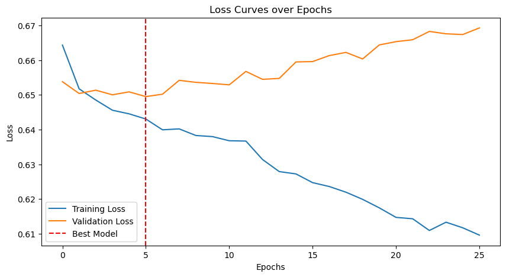

Markdown cell 40

## 7. Performance by Q2 Borrower Segment

We reproduce the Q2 K-Means cluster assignments for the test set and evaluate performance within each segment. The KMeans is refit on the full df_c, then intermediate arrays are immediately deleted to keep memory usage low.

Code cell 41

```
# Reproduce Q2 cluster assignments
cluster_cols = ['loan_amnt', 'int_rate', 'annual_inc_log', 'dti',
                'open_acc', 'revol_bal', 'revol_util', 'total_acc']

df_c = df[['loan_amnt', 'int_rate', 'annual_inc', 'dti',
           'open_acc', 'revol_bal', 'revol_util', 'total_acc']].dropna().copy()
df_c['annual_inc_log'] = np.log1p(df_c['annual_inc'])

# Mahalanobis outlier removal (mirrors Q2)
X_c     = df_c[cluster_cols].values
cov_inv = np.linalg.inv(np.cov(X_c.T))
diff    = X_c - X_c.mean(axis=0)
m_dist  = np.sqrt(np.einsum('ij,jk,ik->i', diff, cov_inv, diff))
df_c    = df_c[m_dist <= np.percentile(m_dist, 99.9)].reset_index(drop=True)
del X_c, cov_inv, diff, m_dist

scaler_c = StandardScaler()
X_cs     = scaler_c.fit_transform(df_c[cluster_cols].values)

np.random.seed(123)
km = KMeans(n_clusters=4, n_init=25, max_iter=100, random_state=123)
km.fit(X_cs)
del X_cs

# Label clusters by income rank (mirrors Q2)
df_c['cluster'] = km.labels_
prof      = df_c.groupby('cluster').agg(avg_inc=('annual_inc', 'mean'),
                                         avg_dti=('dti', 'mean')).reset_index()
inc_rank  = prof.sort_values('avg_inc')['cluster'].values
remaining = prof[prof['cluster'].isin(inc_rank[1:3])].sort_values('avg_dti')['cluster'].values
label_map = {
    inc_rank[0]:  'The Strugglers',
    inc_rank[3]:  'Wealthy but Aggressive',
    remaining[0]: 'Prime Borrowers',
    remaining[1]: 'High Debt-Burden',
}
del df_c
print('Cluster label map:', label_map)
```

```
Cluster label map: {np.int32(1): 'The Strugglers', np.int32(2): 'Wealthy but Aggressive', np.int32(3): 'Prime Borrowers', np.int32(0): 'High Debt-Burden'}
```

Code cell 42

```
# Use idx_test saved during the original split in Section 2d
# — the balanced indices map back into df_model
feat_df = df_model[['loan_amnt', 'int_rate', 'annual_inc', 'dti',
                    'open_acc', 'revol_bal', 'revol_util', 'total_acc']].copy()
feat_df['annual_inc_log'] = np.log1p(feat_df['annual_inc'])

test_clust_X = feat_df.iloc[idx_test][cluster_cols].values
del feat_df

test_segs = np.array([label_map.get(l, 'Unknown')
                      for l in km.predict(scaler_c.transform(test_clust_X))])

print('Performance by Borrower Segment:')
print(f"  {'Segment':<30}  {'N':>5}  {'DR%':>5}  {'AUC':>7}  {'F1':>7}  {'Prec':>7}  {'Rec':>7}")
print('  ' + '-' * 70)
for seg in ['Prime Borrowers', 'High Debt-Burden', 'Wealthy but Aggressive', 'The Strugglers']:
    mask = test_segs == seg
    if not mask.any():
        continue
    ys, ps, prs = all_labels[mask], all_probs[mask], y_pred[mask]
    auc_s = roc_auc_score(ys, ps) if len(np.unique(ys)) > 1 else float('nan')
    print(f"  {seg:<30}  {mask.sum():>5,}  {ys.mean()*100:>4.1f}%  "
          f"{auc_s:>7.4f}  {f1_score(ys,prs,zero_division=0):>7.4f}  "
          f"{precision_score(ys,prs,zero_division=0):>7.4f}  "
          f"{recall_score(ys,prs,zero_division=0):>7.4f}")
```

```
Performance by Borrower Segment:
  Segment                             N    DR%      AUC       F1     Prec      Rec
  ----------------------------------------------------------------------
  Prime Borrowers                   428  47.2%   0.6195   0.6057   0.5409   0.6881
  High Debt-Burden                  565  52.2%   0.6537   0.6407   0.6156   0.6678
  Wealthy but Aggressive            544  49.6%   0.6730   0.6341   0.5820   0.6963
  The Strugglers                    703  50.2%   0.6832   0.6607   0.6047   0.7280
```

Code cell 43

```
# =============================================================================
# Figure 3: ROC Curves by Borrower Segment
# Requires: all_probs, all_labels, test_segs — computed earlier in the notebook
# Uses the same segment colours as Figure 2 (net return chart)
# =============================================================================

from sklearn.metrics import roc_curve, roc_auc_score
import matplotlib.pyplot as plt
import numpy as np

# ── Segment colours — identical to Figure 2 ───────────────────────────────────
seg_styles = {
    'Prime Borrowers':        {'color': '#2d6a4f', 'lw': 1.8},
    'High Debt-Burden':       {'color': '#e07b20', 'lw': 1.8},
    'Wealthy but Aggressive': {'color': '#1a5276', 'lw': 1.8},
    'The Strugglers':         {'color': '#c0392b', 'lw': 1.8},
}

fig, ax = plt.subplots(figsize=(6.5, 5.5))

# Random chance reference line
ax.plot([0, 1], [0, 1], color='#CCCCCC', linewidth=1,
        linestyle=':', zorder=0)
ax.text(0.67, 0.62, 'Random chance', fontsize=8,
        color='#CCCCCC', rotation=38)

# ── Per-segment ROC curves ────────────────────────────────────────────────────
for seg, style in seg_styles.items():
    mask = test_segs == seg
    if not mask.any():
        continue
    ys = all_labels[mask]
    ps = all_probs[mask]
    if len(np.unique(ys)) < 2:
        continue
    fpr, tpr, _ = roc_curve(ys, ps)
    auc_val = roc_auc_score(ys, ps)
    ax.plot(fpr, tpr,
            color=style['color'],
            linewidth=style['lw'],
            label=f"{seg}  (AUC = {auc_val:.2f})",
            zorder=3)

# ── Overall ROC curve — dark navy dashed ──────────────────────────────────────
fpr_all, tpr_all, _ = roc_curve(all_labels, all_probs)
auc_all = roc_auc_score(all_labels, all_probs)
ax.plot(fpr_all, tpr_all,
        color='#1F3864',
        linewidth=2.4,
        linestyle='--',
        label=f"Overall  (AUC = {auc_all:.2f})",
        zorder=4)

# ── Formatting ────────────────────────────────────────────────────────────────
ax.set_xlabel('False Positive Rate', fontsize=10, color='#444444')
ax.set_ylabel('True Positive Rate', fontsize=10, color='#444444')
ax.set_xlim(0, 1)
ax.set_ylim(0, 1)
ax.spines['top'].set_visible(False)
ax.spines['right'].set_visible(False)
ax.spines['left'].set_color('#BBBBBB')
ax.spines['bottom'].set_color('#BBBBBB')
ax.tick_params(colors='#444444')
ax.xaxis.grid(True, color='#EEEEEE', linewidth=0.5, zorder=0)
ax.yaxis.grid(True, color='#EEEEEE', linewidth=0.5, zorder=0)
ax.set_axisbelow(True)

ax.legend(loc='lower right', fontsize=8.5, frameon=True,
          framealpha=0.95, edgecolor='#DDDDDD',
          handlelength=2.2)

ax.set_title('Figure 3: ROC curves by borrower segment — DNN model',
             fontsize=10, fontweight='bold', pad=12,
             color='black', loc='left')

fig.tight_layout()
fig.savefig('fig3_roc_curves.png', bbox_inches='tight',
            facecolor='white', dpi=180)
plt.show()
print(f"Figure 3 saved.  Overall AUC = {auc_all:.4f}")
```

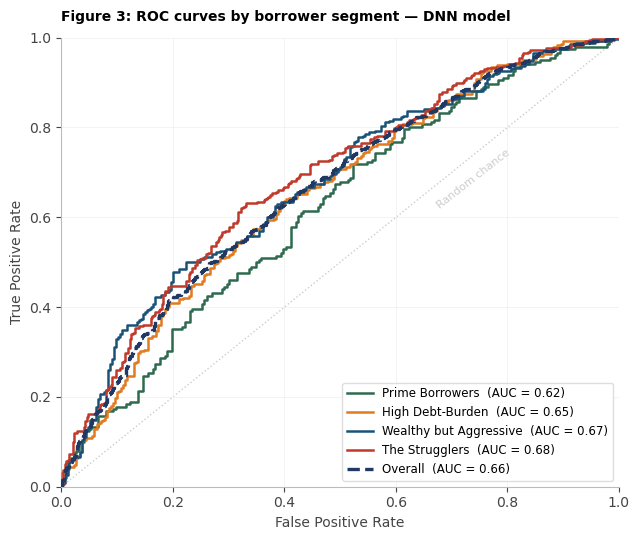

```
Figure 3 saved.  Overall AUC = 0.6617
```

Code cell 44